# COVID-19 Leader Perceptions Registered Report (Main Analyses)

April 05, 2021

```r
rand_seed = 828
set.seed(rand_seed)
```

# Setup

## Package Loading

```r
library(tidyr)
library(dplyr)
library(Hmisc)
library(stringr)
library(lme4)
library(lmerTest)
library(stats)
library(emmeans)
library(kableExtra)
library(estimatr)
library(ggeffects)
library(arm)
library(randomizr)
library(ri2)
library(glmnet)
library(caret)
select <- dplyr::select
```

## Data Loading

```r
df <- read.csv("data.csv", header=TRUE, stringsAsFactors=FALSE)
```

## Set Factor Levels

```r
# Get rid of vars we won't use
df <- select(df, subId, country,
              # Demographics
              gender_recode, age, education, subj_SES, pol_ideology, religiosity,
              # Other vars
              support, check_selfrep, check_voting, taskOrder,
              # Conditions
              argument, dimension, dilemma,
              # DVs
              avg_trust, behav)

# Recode the non-numeric variables
df$gender_recode <- factor(df$gender_recode, levels=c("Female", "Male", "Other"))
df$subId <- factor(df$subId)
df$country <- factor(df$country)

# Format the numeric variables
df <- df %>% mutate_at(c('age', 'education', 'subj_SES', 'religiosity', 'pol_ideology',
                 'support', 'avg_trust'), as.numeric)

# Set factor levels
df <- df %>%
  mutate(dilemma = ifelse(dilemma == "ppe", "PPE", capitalize(dilemma)),
         dilemma = factor(dilemma, levels = c("Lockdown", "Tracing", "Ventilator",
                                              "PPE", "Medicine")))

df <- df %>%
  mutate(dimension = recode(dimension, "IH" = "Instrumental Harm",
                            "IB" = "Impartial Beneficence") ,
         dimension = factor(dimension, levels = c("Instrumental Harm", "Impartial Beneficence")))

df <- df %>%
  mutate(argument = factor(argument, levels = c("Utilitarian", "Non-Utilitarian")))
```

Dimensions: Instrumental Harm, Impartial Beneficence

Arguments: Non-Utilitarian, Utilitarian

Dilemmas: Tracing, Ventilator, Lockdown, PPE, Medicine

## Effect coding

```r
df <- mutate(df,
  argument_recode = recode(argument, "Non-Utilitarian" = -0.5,
                            "Utilitarian" = 0.5),
  dimension_recode = recode(dimension, "Instrumental Harm" = -0.5,
                            "Impartial Beneficence" = 0.5))

# Check
df %>%
  dplyr::select(argument, argument_recode, dimension, dimension_recode) %>%
  unique() %>%
  kable()
```

|  | argument | argument_recode | dimension | dimension_recode |
| --- | --- | --- | --- | --- |
| 1 | Non-Utilitarian | -0.5 | Instrumental Harm | -0.5 |
| 2 | Utilitarian | 0.5 | Instrumental Harm | -0.5 |
| 11982 | Utilitarian | 0.5 | Impartial Beneficence | 0.5 |
| 11984 | Non-Utilitarian | -0.5 | Impartial Beneficence | 0.5 |

## Prepare dvs & scale covariates

### Trust Task

```r
df_self <- df %>%
  # Exclusion criteria 4: missing vars
  filter(!is.na(avg_trust)) %>%
  ungroup() %>%
  select(-behav) %>%
  na.omit() %>%
  # Exclusion criteria 5: failed check
  filter(check_selfrep == 1) %>%
  # Scale
  mutate_at(.funs=list(~ scale(., center = TRUE, scale=FALSE) %>% as.vector),
            vars(age, education, subj_SES, religiosity, pol_ideology, support))
```

17591 subjects in the self reported trust task

### Voting

```r
df_beh <- df %>%
  # Exclusion criteria 4: missing vars
  filter(!is.na(behav)) %>%
  ungroup() %>%
  select(-avg_trust) %>%
  na.omit() %>%
  # Exclusion criteria 5: failed check
  filter(check_voting == 1) %>%
  # Recode answer
  mutate(answer_recode = recode(behav, "Utilitarian" = 1,
                                "Non-Utilitarian" = 0)) %>%
  # Scale
  mutate_at(.funs=list(~scale(., center = TRUE, scale=FALSE) %>% as.vector),
            vars(age, education, subj_SES, religiosity, pol_ideology, support))
```

12638 subjects in the voting task

## Set Contrasts

```r
options(contrasts = c("contr.treatment", "contr.poly")) # Set contrasts
```

Contrasts: contr.treatment, contr.poly

## Formatting Functions

```r
format_output <- function(thisModel){
  model.output <- summary(thisModel)
  model.output <- as.data.frame(model.output$coefficients)
  model.output <- model.output[-1,]
  rownames(model.output) <- rownames(model.output) %>%
                                       capitalize() %>%
                                       gsub("_recode", "", .) %>%
                                       gsub("Pol_ideology", "Political Ideology", .) %>%
                                       gsub("Support", "Policy Support", .) %>%
                                       gsub("Subj_SES", "Subjective SES", .) %>%
                                       gsub('^(Gender)(.*)$', '\\1 [\\2]', .) %>%
                                       gsub("Argument:dimension", "Argument x Dimension", .)
  colnames(model.output) <- colnames(model.output) %>%
                                       gsub("Estimate", "B", .) %>%
                                       gsub("Std. Error", "SE", .) %>%
                                       gsub("t value", "t", .) %>%
                                       gsub("z value", "z", .) %>%
                                       gsub("Pr.*", "p", .)

  for (var in colnames(model.output)) {
    if (var %in% c('B', 'SE', 't', 'z')) {
      model.output[[var]] <- round(model.output[[var]], digits = 2)
    } else if (var == 'p') {
      model.output[[var]] <- format.pval(model.output[[var]], eps = .001, digits = 3)
    } else if (var == 'df') {
      model.output[[var]] <- round(model.output[[var]], digits = 0)
    }
  }

  return(model.output)
}
```

```r
print_output <- function(thisModel, thisIv, thisConf){

  summ <- summary(thisModel)$coefficients

  formatted = (paste("B = ", round(summ[thisIv, 'Estimate'], 2),
  ", SE = ", round(summ[thisIv, 'Std. Error'], 2), sep=''))
  if (class(thisModel)[1] %in% c('glmerMod', 'glm')) {
    formatted = (paste(formatted, ", z = ", round(summ[thisIv, 'z value'], 2),
                     ", p = ", round(summ[thisIv, 'Pr(>|z|)'], 3), sep=''))
  } else if (class(thisModel)[1] == 'lm') {
  formatted = (paste(formatted, ", t = ", round(summ[thisIv, 't value'], 2),
                     ", p = ", round(summ[thisIv, 'Pr(>|t|)'], 3), sep=''))
  } else if (class(thisModel)[1] == 'lm_robust') {
  formatted = (paste(formatted, ", t(", round(summ[thisIv, 'DF'], 0), ") ",
                     "= ", round(summ[thisIv, 't value'], 2),
                     ", p = ", round(summ[thisIv, 'Pr(>|t|)'], 3), sep=''))
  } else {
  formatted = (paste(formatted, ", t(", round(summ[thisIv, 'df'], 0), ") ",
                     "= ", round(summ[thisIv, 't value'], 2),
                     ", p = ", round(summ[thisIv, 'Pr(>|t|)'], 3), sep=''))
  }
  if (is.null(rownames(thisConf))) {
  formatted = (paste(formatted, ", CI = [", round(thisConf[1], 2),
                     ", ", round(thisConf[2], 2), "]", sep=''))

  } else {
  formatted = (paste(formatted, ", CI = [", round(thisConf[thisIv, 1], 2),
                     ", ", round(thisConf[thisIv, 2], 2), "]", sep=''))
  }
  if (class(thisModel)[1] %in% c('glmerMod', 'glm')) {
    formatted = (paste(formatted, ", OR = ", round(exp(summ[thisIv, 'Estimate']), 2), sep=''))
  }
  return(formatted)
}
```

```r
print_output_posthoc <- function(thisEm, thisIv, thisPairs, thisConfPairs){

  formatted = (paste("B = ", round(filter(as.data.frame(thisPairs), dimension_recode == thisIv)['estimate'], 2),
  ", SE = ", round(filter(as.data.frame(thisPairs), dimension_recode == thisIv)['SE'], 2),
  ", t(", round(filter(as.data.frame(thisPairs), dimension_recode == thisIv)['df'], 0), ") ",
  "= ", round(filter(as.data.frame(thisPairs), dimension_recode == thisIv)['t.ratio'], 2),
  ", p = ", round(filter(as.data.frame(thisPairs), dimension_recode == thisIv)['p.value'], 3),
  ", CI = [", round(filter(thisConfPairs, dimension_recode == thisIv)['lower.CL'], 2),
  ", ", round(filter(thisConfPairs, dimension_recode == thisIv)['upper.CL'], 2), "]", sep=''))

  return(formatted)
}
```

```r
print_output_means <- function(thisMeans, thisIv){

  if ('emmean' %in% colnames(thisMeans)) {
    formatted = (paste(round(filter(thisMeans, dimension_recode == thisIv)['emmean'], 2),
    ", SE = ", round(filter(thisMeans, dimension_recode == thisIv)['SE'], 2),
    ", CI = [", round(filter(thisMeans, dimension_recode == thisIv)['lower.CL'], 2),
    ", ", round(filter(thisMeans, dimension_recode == thisIv)['upper.CL'], 2), "]", sep=''))
  } else {
    formatted = (paste(round(filter(thisMeans, dimension_recode == thisIv)['prob'], 2),
    ", SE = ", round(filter(thisMeans, dimension_recode == thisIv)['SE'], 2),
    ", CI = [", round(filter(thisMeans, dimension_recode == thisIv)['asymp.LCL'], 2),
    ", ", round(filter(thisMeans, dimension_recode == thisIv)['asymp.UCL'], 2), "]", sep=''))
  }

  return(formatted)
}
```

# Hypothesis 1: Self report

### 1. Country random intercept

```r
trust_model1 <- lmer(avg_trust ~ gender_recode + age + education + subj_SES
            + pol_ideology + religiosity + support
            + argument_recode + dimension_recode + argument_recode:dimension_recode
            + (1|country/subId) + (1|dilemma),
            data = df_self,
            REML = TRUE)
```

```r
kable(format_output(trust_model1))
```

|  | B | SE | df | t | p |
| --- | --- | --- | --- | --- | --- |
| Gender [Male] | -0.08 | 0.02 | 17562 | -3.77 | <0.001 |
| Gender [Other] | -0.16 | 0.12 | 17562 | -1.34 | 0.181 |
| Age | 0.00 | 0.00 | 17188 | 2.18 | 0.029 |
| Education | 0.00 | 0.01 | 17193 | 0.26 | 0.794 |
| Subjective SES | 0.05 | 0.01 | 17541 | 7.89 | <0.001 |
| Political Ideology | 0.02 | 0.01 | 17608 | 2.94 | 0.003 |
| Religiosity | 0.02 | 0.01 | 16463 | 3.40 | <0.001 |
| Policy Support | 0.05 | 0.00 | 33846 | 13.59 | <0.001 |
| Argument | -0.53 | 0.02 | 17562 | -24.81 | <0.001 |
| Dimension | 0.10 | 0.10 | 3 | 0.95 | 0.408 |
| Argument x Dimension | 2.12 | 0.04 | 17558 | 49.44 | <0.001 |

### 2. Country random slope

```r
trust_model2 <- lmer(avg_trust ~ gender_recode + age + education + subj_SES
            + pol_ideology + religiosity + support
            + argument_recode + dimension_recode + argument_recode:dimension_recode
            + (1 + argument_recode|country) + (1 + dimension_recode|country)
            + (1 + argument_recode:dimension_recode|country)
            + (1|country/subId) + (1|dilemma),
            data = df_self,
            REML = TRUE)
kable(format_output(trust_model2))
```

|  | B | SE | df | t | p |
| --- | --- | --- | --- | --- | --- |
| Gender [Male] | -0.08 | 0.02 | 17519 | -3.78 | <0.001 |
| Gender [Other] | -0.18 | 0.12 | 17524 | -1.53 | 0.126 |
| Age | 0.00 | 0.00 | 16192 | 1.99 | 0.047 |
| Education | 0.00 | 0.01 | 15852 | 0.22 | 0.823 |
| Subjective SES | 0.06 | 0.01 | 17377 | 8.03 | <0.001 |
| Political Ideology | 0.02 | 0.01 | 17515 | 3.09 | 0.002 |
| Religiosity | 0.02 | 0.01 | 15053 | 3.29 | 0.001 |
| Policy Support | 0.05 | 0.00 | 33045 | 13.85 | <0.001 |
| Argument | -0.54 | 0.07 | 21 | -7.73 | <0.001 |
| Dimension | 0.10 | 0.11 | 3 | 0.93 | 0.413 |
| Argument x Dimension | 2.08 | 0.16 | 21 | 13.16 | <0.001 |

Due to convergence issues, we’ll report the first model.

```r
conf <- confint(trust_model1, c("argument_recode", "dimension_recode",
  "argument_recode:dimension_recode"), level = 0.975)
```

```
## Computing profile confidence intervals ...
```

```r
kable(conf)
```

|  | 1.25 % | 98.75 % |
| --- | --- | --- |
| argument_recode | -0.58 | -0.48 |
| dimension_recode | -0.15 | 0.35 |
| argument_recode:dimension_recode | 2.03 | 2.22 |

```r
em <- emmeans(trust_model1,  specs=c("argument_recode", "dimension_recode"),
              adjust="bonferroni",
              lmer.df = "satterthwaite", lmerTest.limit = 35179)
confem <- confint(em, adjust = "bonferroni", level = 0.975)
kable(confem)
```

| argument_recode | dimension_recode | emmean | SE | df | lower.CL | upper.CL |
| --- | --- | --- | --- | --- | --- | --- |
| -0.5 | -0.5 | 4.95 | 0.09 | 12.08 | 4.64 | 5.25 |
| 0.5 | -0.5 | 3.35 | 0.09 | 12.00 | 3.05 | 3.65 |
| -0.5 | 0.5 | 3.98 | 0.10 | 8.47 | 3.61 | 4.35 |
| 0.5 | 0.5 | 4.51 | 0.10 | 8.44 | 4.14 | 4.88 |

```r
pairs = pairs(em, adjust="bonferroni", by="dimension_recode", reverse=TRUE)
kable(pairs)
```

| contrast | dimension_recode | estimate | SE | df | t.ratio | p.value |
| --- | --- | --- | --- | --- | --- | --- |
| 0.5 - (-0.5) | -0.5 | -1.60 | 0.03 | 17559.35 | -52.51 | 0 |
| 0.5 - (-0.5) | 0.5 | 0.53 | 0.03 | 17560.25 | 17.41 | 0 |

```r
confpairs = confint(pairs, level = 0.975)
kable(confpairs)
```

| contrast | dimension_recode | estimate | SE | df | lower.CL | upper.CL |
| --- | --- | --- | --- | --- | --- | --- |
| 0.5 - (-0.5) | -0.5 | -1.60 | 0.03 | 17559.35 | -1.66 | -1.53 |
| 0.5 - (-0.5) | 0.5 | 0.53 | 0.03 | 17560.25 | 0.46 | 0.60 |

Argument: B = -0.53, SE = 0.02, t(17562) = -24.81, p = 0, CI = [-0.58, -0.48]

Dimension: B = 0.1, SE = 0.1, t(3) = 0.95, p = 0.408, CI = [-0.15, 0.35]

Interaction: B = 2.12, SE = 0.04, t(17558) = 49.44, p = 0, CI = [2.03, 2.22]

Instrumental Harm dilemmas:

utilitarian leaders = 3.35, SE = 0.09, CI = [3.05, 3.65]

non-utilitarian leaders = 4.95, SE = 0.09, CI = [4.64, 5.25]

B = -1.6, SE = 0.03, t(17559) = -52.51, p = 0, CI = [-1.66, -1.53]

Impartial Beneficence dilemmas:

utilitarian leaders = 4.51, SE = 0.1, CI = [4.14, 4.88]

non-utilitarian leaders = 3.98, SE = 0.1, CI = [3.61, 4.35]

B = 0.53, SE = 0.03, t(17560) = 17.41, p = 0, CI = [0.46, 0.6]

# Hypothesis 2: Voting

### 1. Logit, country random intercept

```r
beh_model1 <- glmer(answer_recode ~ gender_recode + age + education + subj_SES
               + pol_ideology + religiosity + support
               + dimension_recode
               + (1|country/subId) + (1|dilemma),
               data=df_beh,
               family=binomial(link = "logit"))
```

```
## boundary (singular) fit: see ?isSingular
```

```r
kable(format_output(beh_model1))
```

|  | B | SE | z | p |
| --- | --- | --- | --- | --- |
| Gender [Male] | 0.03 | 0.05 | 0.56 | 0.576 |
| Gender [Other] | -0.92 | 0.26 | -3.53 | <0.001 |
| Age | -0.01 | 0.00 | -4.91 | <0.001 |
| Education | 0.01 | 0.02 | 0.65 | 0.513 |
| Subjective SES | 0.00 | 0.02 | -0.08 | 0.937 |
| Political Ideology | -0.10 | 0.02 | -5.70 | <0.001 |
| Religiosity | -0.01 | 0.01 | -0.74 | 0.458 |
| Policy Support | 0.78 | 0.01 | 57.57 | <0.001 |
| Dimension | 1.37 | 0.33 | 4.21 | <0.001 |

Singular fit, simplify:

```r
beh_model1 <- glmer(answer_recode ~ gender_recode + age + education + subj_SES
               + pol_ideology + religiosity + support
               + dimension_recode
               + (1|country)
               + (1|dilemma),
               data=df_beh,
               family=binomial(link = "logit"))
```

```r
kable(format_output(beh_model1))
```

|  | B | SE | z | p |
| --- | --- | --- | --- | --- |
| Gender [Male] | 0.03 | 0.05 | 0.56 | 0.576 |
| Gender [Other] | -0.92 | 0.26 | -3.53 | <0.001 |
| Age | -0.01 | 0.00 | -4.91 | <0.001 |
| Education | 0.01 | 0.02 | 0.65 | 0.514 |
| Subjective SES | 0.00 | 0.02 | -0.08 | 0.937 |
| Political Ideology | -0.10 | 0.02 | -5.70 | <0.001 |
| Religiosity | -0.01 | 0.01 | -0.74 | 0.458 |
| Policy Support | 0.78 | 0.01 | 57.57 | <0.001 |
| Dimension | 1.37 | 0.32 | 4.21 | <0.001 |

Follow up Tests:

```r
conf <- confint(beh_model1, "dimension_recode", level = 0.975)
```

```
## Computing profile confidence intervals ...
```

```r
kable(conf)
```

|  | 1.25 % | 98.75 % |
| --- | --- | --- |
| dimension_recode | 0.41 | 2.33 |

Marginal Means:

```r
em <- emmeans(beh_model1,  specs=c("dimension_recode"),
              adjust="bonferroni", type = "response",
              lmerTest.limit = 35179)
confem <- confint(em, adjust = "bonferroni", level = 0.975)
kable(confem)
```

| dimension_recode | prob | SE | df | asymp.LCL | asymp.UCL |
| --- | --- | --- | --- | --- | --- |
| -0.5 | 0.21 | 0.04 | Inf | 0.13 | 0.31 |
| 0.5 | 0.50 | 0.07 | Inf | 0.34 | 0.67 |

Dimension: B = 1.37, SE = 0.32, z = 4.21, p = 0, CI = [0.41, 2.33], OR = 3.93

Instrumental Harm dilemmas: 0.21, SE = 0.04, CI = [0.13, 0.31]

Impartial Beneficence dilemmas: 0.5, SE = 0.07, CI = [0.34, 0.67]

```r
write.csv(confem, 'ModelEstimates_Voting.csv', row.names = F)
```

```r
prediction <- ggpredict(beh_model1, "dimension_recode")
```

Prediction: 0.32

### 2. Logit, country random slope

```r
beh_model2 <- glmer(answer_recode ~ gender_recode + age + education + subj_SES
               + pol_ideology + religiosity + support
               + dimension_recode
               + (1 + dimension_recode|country)
               + (1|country/subId) + (1|dilemma),
               data=df_beh,
               family=binomial(link = "logit"))
```

```
## boundary (singular) fit: see ?isSingular
```

```r
kable(format_output(beh_model2))
```

|  | B | SE | z | p |
| --- | --- | --- | --- | --- |
| Gender [Male] | 0.03 | 0.05 | 0.50 | 0.617 |
| Gender [Other] | -0.93 | 0.26 | -3.60 | <0.001 |
| Age | -0.01 | 0.00 | -4.88 | <0.001 |
| Education | 0.01 | 0.02 | 0.59 | 0.556 |
| Subjective SES | 0.00 | 0.02 | -0.14 | 0.885 |
| Political Ideology | -0.10 | 0.02 | -5.75 | <0.001 |
| Religiosity | -0.01 | 0.01 | -0.74 | 0.458 |
| Policy Support | 0.78 | 0.01 | 57.33 | <0.001 |
| Dimension | 1.36 | 0.33 | 4.12 | <0.001 |

Singular fit, simplify:

```r
beh_model2 <- glmer(answer_recode ~ gender_recode + age + education + subj_SES
               + pol_ideology + religiosity + support
               + dimension_recode
               + (1 + dimension_recode|country)
               + (1|country) + (1|dilemma),
               data=df_beh,
               family=binomial(link = "logit"))
kable(format_output(beh_model2))
```

|  | B | SE | z | p |
| --- | --- | --- | --- | --- |
| Gender [Male] | 0.03 | 0.05 | 0.50 | 0.617 |
| Gender [Other] | -0.93 | 0.26 | -3.60 | <0.001 |
| Age | -0.01 | 0.00 | -4.88 | <0.001 |
| Education | 0.01 | 0.02 | 0.59 | 0.555 |
| Subjective SES | 0.00 | 0.02 | -0.14 | 0.885 |
| Political Ideology | -0.10 | 0.02 | -5.75 | <0.001 |
| Religiosity | -0.01 | 0.01 | -0.74 | 0.458 |
| Policy Support | 0.78 | 0.01 | 57.33 | <0.001 |
| Dimension | 1.36 | 0.33 | 4.12 | <0.001 |

### 3. Linear, country random intercept

```r
beh_model3 <- lmer(answer_recode ~ gender_recode + age + education + subj_SES
               + pol_ideology + religiosity + support
               + dimension_recode
               + (1|country)
               + (1|dilemma),
               data=df_beh,
               REML = TRUE)
```

```r
kable(format_output(beh_model3))
```

|  | B | SE | df | t | p |
| --- | --- | --- | --- | --- | --- |
| Gender [Male] | 0.00 | 0.01 | 12620 | 0.40 | 0.688 |
| Gender [Other] | -0.12 | 0.03 | 12622 | -3.52 | <0.001 |
| Age | 0.00 | 0.00 | 9945 | -4.74 | <0.001 |
| Education | 0.00 | 0.00 | 9304 | 0.80 | 0.426 |
| Subjective SES | 0.00 | 0.00 | 11990 | 0.10 | 0.922 |
| Political Ideology | -0.01 | 0.00 | 12416 | -6.09 | <0.001 |
| Religiosity | 0.00 | 0.00 | 6921 | -0.53 | 0.594 |
| Policy Support | 0.13 | 0.00 | 12590 | 89.88 | <0.001 |
| Dimension | 0.18 | 0.05 | 3 | 3.73 | 0.034 |

Follow up Tests:

```r
conf <- confint(beh_model3, c("dimension_recode"), level = 0.975)
```

```
## Computing profile confidence intervals ...
```

```r
kable(conf)
```

|  | 1.25 % | 98.75 % |
| --- | --- | --- |
| dimension_recode | 0.07 | 0.3 |

```r
em <- emmeans(beh_model3,  specs=c("dimension_recode"), adjust="bonferroni",
              lmer.df = "satterthwaite", lmerTest.limit = 35179)
confem <- confint(em, adjust = "bonferroni", level = 0.975)
kable(confem)
```

| dimension_recode | emmean | SE | df | lower.CL | upper.CL |
| --- | --- | --- | --- | --- | --- |
| -0.5 | 0.30 | 0.03 | 4.14 | 0.16 | 0.45 |
| 0.5 | 0.49 | 0.04 | 3.70 | 0.31 | 0.67 |

Dimension: B = 0.18, SE = 0.05, t(3) = 3.73, p = 0.034, CI = [0.07, 0.3]

Instrumental Harm dilemmas: 0.3, SE = 0.03, CI = [0.16, 0.45]

Impartial Beneficence dilemmas: 0.49, SE = 0.04, CI = [0.31, 0.67]

```r
prediction <- ggpredict(beh_model3, "dimension_recode")
```

Prediction: 0.18

### TOST

```
## TOST results:
## Z-value lower bound: 56.70   p-value lower bound: 0.000
## Z-value upper bound: 20.77   p-value upper bound: 1.000
##
## Equivalence bounds:
## low eqbound: -0.15
## high eqbound: 0.15
##
## TOST confidence interval:
## lower bound 90% CI: 0.31
## upper bound 90% CI:  0.337
##
## NHST confidence interval:
## lower bound 95% CI: 0.307
## upper bound 95% CI:  0.34
##
## Equivalence Test based on Fisher's exact z-test Result:
## The equivalence test was non-significant, Z = 20.767, p = 1.000, given equivalence bounds of -0.150 and 0.150 and an alpha of 0.05.
```

```
##
## Null-Hypothesis Fisher's exact z-test Result:
## The null hypothesis test was significant, Z = 38.736, p = 0.000, given an alpha of 0.05.
```

```
##
## Based on the equivalence test and the null-hypothesis test combined, we can conclude that the observed effect is statistically different from zero and statistically not equivalent to zero.
```

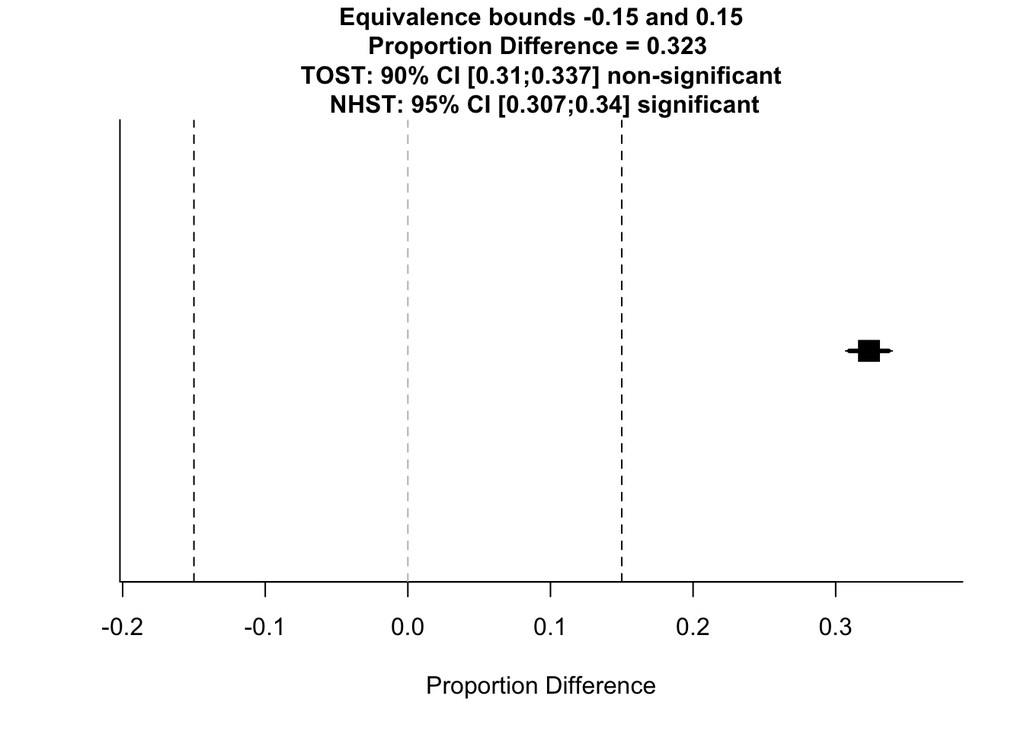

```r
df_beh %>%
  group_by(answer_recode, dimension_recode) %>%
  summarise(counts=n(), .groups = "drop") %>%
  group_by(dimension_recode) %>%
  mutate(total=sum(counts)) %>%
  ungroup() %>%
  mutate(prop=counts/total) %>%
  filter(answer_recode==1) -> props

# ΔL = -0.15 and ΔU = 0.15
TOSTER::TOSTtwo.prop(prop1=props$prop[props$dimension_recode==0.5],
                     prop2=props$prop[props$dimension_recode==-0.5],
                     n1=props$total[props$dimension_recode==0.5],
                     n2=props$total[props$dimension_recode==-0.5],
                     low_eqbound = -0.15,
                     high_eqbound = 0.15,
                     alpha = .05, plot = TRUE, verbose = TRUE)
```

### 4. Logit, no random effects

```r
beh_model4 <- glm(answer_recode ~ gender_recode + age + education + subj_SES
               + pol_ideology + religiosity + support
               + dimension_recode,
               data=df_beh,
               family=binomial(link = "logit"))
```

```r
kable(format_output(beh_model4))
```

|  | B | SE | z | p |
| --- | --- | --- | --- | --- |
| Gender [Male] | 0.03 | 0.05 | 0.60 | 0.551 |
| Gender [Other] | -0.96 | 0.26 | -3.76 | <0.001 |
| Age | -0.01 | 0.00 | -4.82 | <0.001 |
| Education | 0.00 | 0.02 | -0.15 | 0.881 |
| Subjective SES | 0.00 | 0.02 | -0.09 | 0.925 |
| Political Ideology | -0.09 | 0.02 | -5.46 | <0.001 |
| Religiosity | 0.00 | 0.01 | 0.31 | 0.759 |
| Policy Support | 0.77 | 0.01 | 58.97 | <0.001 |
| Dimension | 1.34 | 0.05 | 26.38 | <0.001 |

Follow up Tests:

```r
conf <- confint(beh_model4, "dimension_recode", level = 0.975)
kable(conf)
```

|  | x |
| --- | --- |
| 1.3 % | 1.22 |
| 98.8 % | 1.45 |

Marginal Means:

```r
em <- emmeans(beh_model4,  specs=c("dimension_recode"),
              adjust="bonferroni", type = "response",
              lmerTest.limit = 35179)
confem <- confint(em, adjust = "bonferroni", level = 0.975)
kable(confem)
```

| dimension_recode | prob | SE | df | asymp.LCL | asymp.UCL |
| --- | --- | --- | --- | --- | --- |
| -0.5 | 0.21 | 0.02 | Inf | 0.17 | 0.25 |
| 0.5 | 0.50 | 0.02 | Inf | 0.45 | 0.56 |

Dimension: B = 1.34, SE = 0.05, z = 26.38, p = 0, CI = [1.22, 1.45], OR = 3.8

Instrumental Harm dilemmas: 0.21, SE = 0.02, CI = [0.17, 0.25]

Impartial Beneficence dilemmas: 0.5, SE = 0.02, CI = [0.45, 0.56]

```r
prediction <- ggpredict(beh_model4, "dimension_recode")
```

Prediction: 0.31

### 5. Linear, no random effects

```r
beh_model5 <- lm(answer_recode ~ gender_recode + age + education + subj_SES
               + pol_ideology + religiosity + support
               + dimension_recode,
               data=df_beh)
```

```r
kable(format_output(beh_model5))
```

|  | B | SE | t | p |
| --- | --- | --- | --- | --- |
| Gender [Male] | 0.00 | 0.01 | 0.43 | 0.669 |
| Gender [Other] | -0.13 | 0.03 | -3.76 | <0.001 |
| Age | 0.00 | 0.00 | -4.77 | <0.001 |
| Education | 0.00 | 0.00 | -0.17 | 0.862 |
| Subjective SES | 0.00 | 0.00 | 0.30 | 0.768 |
| Political Ideology | -0.01 | 0.00 | -5.79 | <0.001 |
| Religiosity | 0.00 | 0.00 | 0.18 | 0.860 |
| Policy Support | 0.13 | 0.00 | 91.87 | <0.001 |
| Dimension | 0.19 | 0.01 | 28.05 | <0.001 |

Follow up Tests:

```r
conf <- confint(beh_model5, c("dimension_recode"), level = 0.975)
kable(conf)
```

|  | 1.25 % | 98.75 % |
| --- | --- | --- |
| dimension_recode | 0.17 | 0.2 |

```r
em <- emmeans(beh_model5,  specs=c("dimension_recode"), adjust="bonferroni",
              lmer.df = "satterthwaite", lmerTest.limit = 35179)
confem <- confint(em, adjust = "bonferroni", level = 0.975)
kable(confem)
```

| dimension_recode | emmean | SE | df | lower.CL | upper.CL |
| --- | --- | --- | --- | --- | --- |
| -0.5 | 0.30 | 0.01 | 12628 | 0.27 | 0.33 |
| 0.5 | 0.49 | 0.01 | 12628 | 0.46 | 0.52 |

Dimension: B = 0.19, SE = 0.01, t = 28.05, p = 0, CI = [0.17, 0.2]

Instrumental Harm dilemmas: 0.3, SE = 0.01, CI = [0.27, 0.33]

Impartial Beneficence dilemmas: 0.49, SE = 0.01, CI = [0.46, 0.52]

```r
prediction <- ggpredict(beh_model5, "dimension_recode")
```

Prediction: 0.19

### 6. Logit, no covariates

```r
beh_model6 <- glm(answer_recode ~ dimension_recode,
               data=df_beh,
               family=binomial(link = "logit"))
```

```r
kable(format_output(beh_model6))
```

|  | B | SE | z | p |
| --- | --- | --- | --- | --- |
| Dimension | 1.37 | 0.04 | 35.9 | <0.001 |

Follow up Tests:

```r
conf <- confint(beh_model6, "dimension_recode", level = 0.975)
kable(conf)
```

|  | x |
| --- | --- |
| 1.3 % | 1.28 |
| 98.8 % | 1.45 |

Marginal Means:

```r
em <- emmeans(beh_model6,  specs=c("dimension_recode"),
              adjust="bonferroni", type = "response",
              lmerTest.limit = 35179)
confem <- confint(em, adjust = "bonferroni", level = 0.975)
kable(confem)
```

| dimension_recode | prob | SE | df | asymp.LCL | asymp.UCL |
| --- | --- | --- | --- | --- | --- |
| -0.5 | 0.28 | 0.01 | Inf | 0.26 | 0.29 |
| 0.5 | 0.60 | 0.01 | Inf | 0.58 | 0.61 |

Dimension: B = 1.37, SE = 0.04, z = 35.9, p = 0, CI = [1.28, 1.45], OR = 3.92

Instrumental Harm dilemmas: 0.28, SE = 0.01, CI = [0.26, 0.29]

Impartial Beneficence dilemmas: 0.6, SE = 0.01, CI = [0.58, 0.61]

```r
prediction <- ggpredict(beh_model6, "dimension_recode")
```

Prediction: 0.32

### 7. Linear, no covariates

```r
beh_model7 <- lm(answer_recode ~ dimension_recode,
               data=df_beh)
```

```r
kable(format_output(beh_model7))
```

|  | B | SE | t | p |
| --- | --- | --- | --- | --- |
| Dimension | 0.32 | 0.01 | 38.76 | <0.001 |

Follow up Tests:

```r
conf <- confint(beh_model7, c("dimension_recode"), level = 0.975)
kable(conf)
```

|  | 1.25 % | 98.75 % |
| --- | --- | --- |
| dimension_recode | 0.3 | 0.34 |

```r
em <- emmeans(beh_model7,  specs=c("dimension_recode"), adjust="bonferroni",
              lmer.df = "satterthwaite", lmerTest.limit = 35179)
confem <- confint(em, adjust = "bonferroni", level = 0.975)
kable(confem)
```

| dimension_recode | emmean | SE | df | lower.CL | upper.CL |
| --- | --- | --- | --- | --- | --- |
| -0.5 | 0.28 | 0.01 | 12636 | 0.26 | 0.29 |
| 0.5 | 0.60 | 0.01 | 12636 | 0.58 | 0.61 |

Dimension: B = 0.32, SE = 0.01, t = 38.76, p = 0, CI = [0.3, 0.34]

Instrumental Harm dilemmas: 0.28, SE = 0.01, CI = [0.26, 0.29]

Impartial Beneficence dilemmas: 0.6, SE = 0.01, CI = [0.58, 0.61]

```r
prediction <- ggpredict(beh_model7, "dimension_recode")
```

Prediction: 0.32

### 8. Logit, country fixed

```r
beh_model8 <- glm(answer_recode ~ gender_recode + age + education + subj_SES
               + pol_ideology + religiosity + support + country
               + dimension_recode,
               data=df_beh,
               family=binomial(link = "logit"))
```

```r
kable(format_output(beh_model8))
```

|  | B | SE | z | p |
| --- | --- | --- | --- | --- |
| Gender [Male] | 0.03 | 0.05 | 0.61 | 0.542 |
| Gender [Other] | -0.85 | 0.26 | -3.30 | <0.001 |
| Age | -0.01 | 0.00 | -4.47 | <0.001 |
| Education | 0.02 | 0.02 | 0.83 | 0.408 |
| Subjective SES | 0.00 | 0.02 | -0.23 | 0.820 |
| Political Ideology | -0.10 | 0.02 | -5.62 | <0.001 |
| Religiosity | -0.01 | 0.01 | -0.92 | 0.356 |
| Policy Support | 0.78 | 0.01 | 58.40 | <0.001 |
| CountryBrazil | -0.20 | 0.17 | -1.14 | 0.256 |
| CountryCanada | -0.39 | 0.15 | -2.53 | 0.011 |
| CountryChile | -0.36 | 0.17 | -2.12 | 0.034 |
| CountryChina | -1.01 | 0.16 | -6.49 | <0.001 |
| CountryDenmark | -0.24 | 0.15 | -1.54 | 0.124 |
| CountryFrance | -0.15 | 0.16 | -0.94 | 0.348 |
| CountryGermany | -0.19 | 0.15 | -1.25 | 0.212 |
| CountryIndia | -0.15 | 0.16 | -0.96 | 0.335 |
| CountryIsrael | -0.67 | 0.19 | -3.42 | <0.001 |
| CountryItaly | -0.28 | 0.19 | -1.52 | 0.129 |
| CountryKingdom of Saudi Arabia | -0.34 | 0.18 | -1.82 | 0.069 |
| CountryMexico | -0.57 | 0.17 | -3.29 | 0.001 |
| CountryNorway | 0.09 | 0.17 | 0.50 | 0.614 |
| CountrySingapore | -0.26 | 0.17 | -1.52 | 0.129 |
| CountrySouth Africa | -0.02 | 0.16 | -0.15 | 0.883 |
| CountrySouth Korea | -0.66 | 0.18 | -3.58 | <0.001 |
| CountrySpain | -0.48 | 0.17 | -2.85 | 0.004 |
| CountryThe Netherlands | -0.33 | 0.15 | -2.22 | 0.027 |
| CountryUnited Arab Emirates | 0.18 | 0.19 | 0.95 | 0.343 |
| CountryUnited Kingdom | -0.06 | 0.15 | -0.41 | 0.685 |
| CountryUnited States | -0.32 | 0.15 | -2.12 | 0.034 |
| Dimension | 1.34 | 0.05 | 26.37 | <0.001 |

Follow up Tests:

```r
conf <- confint(beh_model8, "dimension_recode", level = 0.975)
kable(conf)
```

|  | x |
| --- | --- |
| 1.3 % | 1.23 |
| 98.8 % | 1.46 |

Marginal Means:

```r
em <- emmeans(beh_model8,  specs=c("dimension_recode"),
              adjust="bonferroni", type = "response",
              lmerTest.limit = 35179)
confem <- confint(em, adjust = "bonferroni", level = 0.975)
kable(confem)
```

| dimension_recode | prob | SE | df | asymp.LCL | asymp.UCL |
| --- | --- | --- | --- | --- | --- |
| -0.5 | 0.21 | 0.02 | Inf | 0.18 | 0.25 |
| 0.5 | 0.51 | 0.02 | Inf | 0.45 | 0.57 |

Dimension: B = 1.34, SE = 0.05, z = 26.37, p = 0, CI = [1.23, 1.46], OR = 3.84

Instrumental Harm dilemmas: 0.21, SE = 0.02, CI = [0.18, 0.25]

Impartial Beneficence dilemmas: 0.51, SE = 0.02, CI = [0.45, 0.57]

```r
prediction <- ggpredict(beh_model8, "dimension_recode")
```

Prediction: 0.32

### 9. Linear, country fixed

```r
beh_model9 <- lm(answer_recode ~ gender_recode + age + education + subj_SES
               + pol_ideology + religiosity + support + country
               + dimension_recode,
               data=df_beh)
```

```r
kable(format_output(beh_model9))
```

|  | B | SE | t | p |
| --- | --- | --- | --- | --- |
| Gender [Male] | 0.00 | 0.01 | 0.50 | 0.618 |
| Gender [Other] | -0.12 | 0.03 | -3.35 | <0.001 |
| Age | 0.00 | 0.00 | -4.57 | <0.001 |
| Education | 0.00 | 0.00 | 0.97 | 0.332 |
| Subjective SES | 0.00 | 0.00 | 0.07 | 0.942 |
| Political Ideology | -0.01 | 0.00 | -5.83 | <0.001 |
| Religiosity | 0.00 | 0.00 | -0.92 | 0.357 |
| Policy Support | 0.13 | 0.00 | 91.10 | <0.001 |
| CountryBrazil | -0.03 | 0.02 | -1.33 | 0.184 |
| CountryCanada | -0.05 | 0.02 | -2.65 | 0.008 |
| CountryChile | -0.06 | 0.02 | -2.57 | 0.010 |
| CountryChina | -0.13 | 0.02 | -6.40 | <0.001 |
| CountryDenmark | -0.03 | 0.02 | -1.36 | 0.175 |
| CountryFrance | -0.02 | 0.02 | -0.85 | 0.397 |
| CountryGermany | -0.02 | 0.02 | -1.01 | 0.312 |
| CountryIndia | -0.03 | 0.02 | -1.26 | 0.207 |
| CountryIsrael | -0.09 | 0.03 | -3.53 | <0.001 |
| CountryItaly | -0.04 | 0.02 | -1.55 | 0.121 |
| CountryKingdom of Saudi Arabia | -0.04 | 0.02 | -1.82 | 0.069 |
| CountryMexico | -0.07 | 0.02 | -3.36 | <0.001 |
| CountryNorway | 0.01 | 0.02 | 0.57 | 0.570 |
| CountrySingapore | -0.03 | 0.02 | -1.45 | 0.148 |
| CountrySouth Africa | -0.01 | 0.02 | -0.39 | 0.700 |
| CountrySouth Korea | -0.09 | 0.02 | -3.85 | <0.001 |
| CountrySpain | -0.07 | 0.02 | -3.00 | 0.003 |
| CountryThe Netherlands | -0.04 | 0.02 | -2.18 | 0.029 |
| CountryUnited Arab Emirates | 0.01 | 0.02 | 0.63 | 0.531 |
| CountryUnited Kingdom | 0.00 | 0.02 | -0.22 | 0.824 |
| CountryUnited States | -0.04 | 0.02 | -2.00 | 0.045 |
| Dimension | 0.19 | 0.01 | 28.08 | <0.001 |

Follow up Tests:

```r
conf <- confint(beh_model9, c("dimension_recode"), level = 0.975)
kable(conf)
```

|  | 1.25 % | 98.75 % |
| --- | --- | --- |
| dimension_recode | 0.17 | 0.2 |

```r
em <- emmeans(beh_model9,  specs=c("dimension_recode"), adjust="bonferroni",
              lmer.df = "satterthwaite", lmerTest.limit = 35179)
confem <- confint(em, adjust = "bonferroni", level = 0.975)
kable(confem)
```

| dimension_recode | emmean | SE | df | lower.CL | upper.CL |
| --- | --- | --- | --- | --- | --- |
| -0.5 | 0.31 | 0.01 | 12607 | 0.27 | 0.34 |
| 0.5 | 0.49 | 0.01 | 12607 | 0.46 | 0.52 |

Dimension: B = 0.19, SE = 0.01, t = 28.08, p = 0, CI = [0.17, 0.2]

Instrumental Harm dilemmas: 0.31, SE = 0.01, CI = [0.27, 0.34]

Impartial Beneficence dilemmas: 0.49, SE = 0.01, CI = [0.46, 0.52]

```r
prediction <- ggpredict(beh_model9, "dimension_recode")
```

Prediction: 0.19

### 10. Linear, robust SEs

```r
beh_model10 <- lm_robust(answer_recode ~ gender_recode + age + education + subj_SES
               + pol_ideology + religiosity + support
               + dimension_recode,
               clusters = country,
               data=df_beh)
```

```r
kable(format_output(beh_model10))
```

|  | B | SE | t | p | CI Lower | CI Upper | DF |
| --- | --- | --- | --- | --- | --- | --- | --- |
| Gender [Male] | 0.00 | 0.01 | 0.39 | 0.704 | -0.01 | 0.02 | 19.95 |
| Gender [Other] | -0.13 | 0.05 | -2.82 | 0.017 | -0.23 | -0.03 | 10.66 |
| Age | 0.00 | 0.00 | -3.19 | 0.005 | 0.00 | 0.00 | 18.82 |
| Education | 0.00 | 0.00 | -0.13 | 0.902 | -0.01 | 0.01 | 17.53 |
| Subjective SES | 0.00 | 0.00 | 0.24 | 0.816 | 0.00 | 0.01 | 19.33 |
| Political Ideology | -0.01 | 0.00 | -5.02 | <0.001 | -0.02 | -0.01 | 19.32 |
| Religiosity | 0.00 | 0.00 | 0.13 | 0.901 | 0.00 | 0.01 | 19.00 |
| Policy Support | 0.13 | 0.00 | 33.93 | <0.001 | 0.12 | 0.14 | 19.40 |
| Dimension | 0.19 | 0.01 | 15.78 | <0.001 | 0.16 | 0.21 | 19.90 |

Follow up Tests:

```r
conf <- confint(beh_model10, c("dimension_recode"), level = 0.975)
kable(conf)
```

|  | 1.25 % | 98.75 % |
| --- | --- | --- |
| dimension_recode | 0.16 | 0.21 |

```r
em <- emmeans(beh_model10,  specs=c("dimension_recode"), adjust="bonferroni",
              lmer.df = "satterthwaite", lmerTest.limit = 35179)
confem <- confint(em, adjust = "bonferroni", level = 0.975)
kable(confem)
```

| dimension_recode | emmean | SE | df | lower.CL | upper.CL |
| --- | --- | --- | --- | --- | --- |
| -0.5 | 0.30 | 0.02 | 12628 | 0.26 | 0.35 |
| 0.5 | 0.49 | 0.02 | 12628 | 0.43 | 0.54 |

Dimension: B = 0.19, SE = 0.01, t(20) = 15.78, p = 0, CI = [0.16, 0.21]

Instrumental Harm dilemmas: 0.3, SE = 0.02, CI = [0.26, 0.35]

Impartial Beneficence dilemmas: 0.49, SE = 0.02, CI = [0.43, 0.54]

```r
prediction <- ggpredict(beh_model10, "dimension_recode")
```

Prediction: 0.19

# Country coefficients

### Self Report

```r
srep_model <- lmer(avg_trust ~ gender_recode + age + education + subj_SES
            + pol_ideology + religiosity + support
            + argument_recode + dimension_recode + argument_recode:dimension_recode
            + (1 + argument_recode*dimension_recode|country),
            data = df_self,
            REML = TRUE)
coefficients_srep <- coef(srep_model)$country
coefficients_srep <- rbind(coefficients_srep, Overall=fixef(srep_model))
coefficients_srep$country <- rownames(coefficients_srep)

errors <- se.coef(srep_model)$country
errors <- rbind(errors, overall=se.fixef(srep_model)[c(1, 12)])
colnames(errors) <- paste(colnames(errors), '_error', sep = '')
write.csv(cbind(coefficients_srep, errors), 'CountryCoeffs_SelfRep.csv', row.names = F)
```

```r
kable(format_output(srep_model))
```

|  | B | SE | df | t | p |
| --- | --- | --- | --- | --- | --- |
| Gender [Male] | -0.08 | 0.02 | 35122 | -4.62 | <0.001 |
| Gender [Other] | -0.18 | 0.10 | 35124 | -1.88 | 0.060 |
| Age | 0.00 | 0.00 | 32463 | 2.54 | 0.011 |
| Education | 0.00 | 0.01 | 32251 | 0.20 | 0.844 |
| Subjective SES | 0.05 | 0.01 | 34813 | 9.69 | <0.001 |
| Political Ideology | 0.02 | 0.01 | 35023 | 3.78 | <0.001 |
| Religiosity | 0.02 | 0.00 | 30438 | 3.95 | <0.001 |
| Policy Support | 0.06 | 0.00 | 33662 | 14.47 | <0.001 |
| Argument | -0.54 | 0.07 | 21 | -7.68 | <0.001 |
| Dimension | 0.09 | 0.03 | 21 | 2.92 | 0.008 |
| Argument x Dimension | 2.08 | 0.16 | 21 | 13.08 | <0.001 |

```r
conf <- confint(srep_model, c("argument_recode:dimension_recode"), level = 0.975)
```

```
## Computing profile confidence intervals ...
```

```r
kable(conf)
```

|  | 1.25 % | 98.75 % |
| --- | --- | --- |
| argument_recode:dimension_recode | 1.71 | 2.45 |

Interaction: B = 2.08, SE = 0.16, t(21) = 13.08, p = 0, CI = [1.71, 2.45]

### Voting

```r
vot_model <- glmer(answer_recode ~ gender_recode + age + education + subj_SES
               + pol_ideology + religiosity + support
               + dimension_recode
               + (1 + dimension_recode|country),
               data=df_beh,
               family=binomial(link = "logit"))
```

```r
coefficients_vot <- coef(vot_model)$country
coefficients_vot <- rbind(coefficients_vot, Overall=fixef(vot_model))
coefficients_vot$country <- rownames(coefficients_vot)

errors <- se.coef(vot_model)$country
errors <- rbind(errors, overall=se.fixef(vot_model)[c(1, 10)])
colnames(errors) <- paste(colnames(errors), '_error', sep = '')
write.csv(cbind(coefficients_vot, errors), 'CountryCoeffs_Voting.csv', row.names = F)
```

```r
kable(format_output(vot_model))
```

|  | B | SE | z | p |
| --- | --- | --- | --- | --- |
| Gender [Male] | 0.03 | 0.05 | 0.55 | 0.584 |
| Gender [Other] | -0.89 | 0.26 | -3.45 | <0.001 |
| Age | -0.01 | 0.00 | -4.63 | <0.001 |
| Education | 0.01 | 0.02 | 0.60 | 0.550 |
| Subjective SES | 0.00 | 0.02 | -0.30 | 0.768 |
| Political Ideology | -0.10 | 0.02 | -5.62 | <0.001 |
| Religiosity | -0.01 | 0.01 | -0.62 | 0.537 |
| Policy Support | 0.78 | 0.01 | 58.29 | <0.001 |
| Dimension | 1.34 | 0.07 | 17.88 | <0.001 |

```r
conf <- confint(vot_model, "dimension_recode", level = 0.975)
```

```
## Computing profile confidence intervals ...
```

```r
kable(conf)
```

|  | 1.25 % | 98.75 % |
| --- | --- | --- |
| dimension_recode | 1.16 | 1.51 |

Dimension: B = 1.34, SE = 0.07, z = 17.88, p = 0, CI = [1.16, 1.51], OR = 3.81

```r
corr <- cor.test(coefficients_srep$`argument_recode:dimension_recode`,
         coefficients_vot$dimension_recode)
```

Correlation between self report task and voting task across countries: r=0.76, p=0

# Robustness checks

We will re run the winning models a couple different ways:

## Exclude Lockdown dilemma

### Self Report

```r
trust_model1 <- lmer(avg_trust ~ gender_recode + age + education + subj_SES
            + pol_ideology + religiosity + support
            + argument_recode + dimension_recode + argument_recode:dimension_recode
            + (1|country/subId) + (1|dilemma),
            data = filter(df_self, dilemma != "Lockdown"),
            REML = TRUE)
```

```r
kable(format_output(trust_model1))
```

|  | B | SE | df | t | p |
| --- | --- | --- | --- | --- | --- |
| Gender [Male] | -0.08 | 0.02 | 17410 | -3.47 | <0.001 |
| Gender [Other] | -0.17 | 0.13 | 17251 | -1.32 | 0.188 |
| Age | 0.00 | 0.00 | 16932 | 1.64 | 0.100 |
| Education | 0.00 | 0.01 | 16952 | 0.29 | 0.768 |
| Subjective SES | 0.05 | 0.01 | 17418 | 6.89 | <0.001 |
| Political Ideology | 0.02 | 0.01 | 17498 | 2.86 | 0.004 |
| Religiosity | 0.02 | 0.01 | 16049 | 3.41 | <0.001 |
| Policy Support | 0.05 | 0.00 | 27431 | 12.30 | <0.001 |
| Argument | -0.60 | 0.02 | 17646 | -25.88 | <0.001 |
| Dimension | 0.14 | 0.12 | 2 | 1.19 | 0.350 |
| Argument x Dimension | 2.26 | 0.05 | 17640 | 48.56 | <0.001 |

```r
conf <- confint(trust_model1, c("argument_recode:dimension_recode"), level = 0.975)
```

```
## Computing profile confidence intervals ...
```

```r
kable(conf)
```

|  | 1.25 % | 98.75 % |
| --- | --- | --- |
| argument_recode:dimension_recode | 2.16 | 2.37 |

Interaction: B = 2.26, SE = 0.05, t(17640) = 48.56, p = 0, CI = [2.16, 2.37]

### Voting

```r
beh_model1 <- glmer(answer_recode ~ gender_recode + age + education + subj_SES
               + pol_ideology + religiosity + support
               + dimension_recode
               + (1|country)
               + (1|dilemma),
               data=filter(df_beh, dilemma != "Lockdown"),
               family=binomial(link = "logit"))
```

```r
kable(format_output(beh_model1))
```

|  | B | SE | z | p |
| --- | --- | --- | --- | --- |
| Gender [Male] | 0.02 | 0.06 | 0.43 | 0.664 |
| Gender [Other] | -1.05 | 0.27 | -3.87 | <0.001 |
| Age | -0.01 | 0.00 | -5.14 | <0.001 |
| Education | 0.03 | 0.02 | 1.15 | 0.251 |
| Subjective SES | -0.01 | 0.02 | -0.43 | 0.669 |
| Political Ideology | -0.13 | 0.02 | -6.85 | <0.001 |
| Religiosity | -0.01 | 0.02 | -0.91 | 0.363 |
| Policy Support | 0.76 | 0.01 | 52.12 | <0.001 |
| Dimension | 1.29 | 0.39 | 3.33 | <0.001 |

```r
conf <- confint(beh_model1, "dimension_recode", level = 0.975)
```

```
## Computing profile confidence intervals ...
```

```r
kable(conf)
```

|  | 1.25 % | 98.75 % |
| --- | --- | --- |
| dimension_recode | 0.06 | 2.52 |

Dimension: B = 1.29, SE = 0.39, z = 3.33, p = 0.001, CI = [0.06, 2.52], OR = 3.63

## In countries where contact tracing has already been implemented:

### Self Report with Tracing

```r
trust_model1 <- lmer(avg_trust ~ gender_recode + age + education + subj_SES
            + pol_ideology + religiosity + support
            + argument_recode + dimension_recode + argument_recode:dimension_recode
            + (1|country/subId) + (1|dilemma),
            data = filter(df_self, country %in% c("China", "India", "Israel", "Singapore", "South Korea")),
            REML = TRUE)
```

```r
kable(format_output(trust_model1))
```

|  | B | SE | df | t | p |
| --- | --- | --- | --- | --- | --- |
| Gender [Male] | -0.08 | 0.05 | 3267 | -1.58 | 0.115 |
| Gender [Other] | 0.45 | 0.26 | 3269 | 1.77 | 0.077 |
| Age | 0.01 | 0.00 | 3286 | 6.85 | <0.001 |
| Education | -0.02 | 0.02 | 3269 | -1.04 | 0.299 |
| Subjective SES | 0.10 | 0.02 | 3271 | 6.20 | <0.001 |
| Political Ideology | 0.04 | 0.02 | 3271 | 2.22 | 0.027 |
| Religiosity | 0.05 | 0.01 | 3232 | 3.38 | <0.001 |
| Policy Support | 0.08 | 0.01 | 6254 | 9.61 | <0.001 |
| Argument | -0.68 | 0.05 | 3266 | -13.97 | <0.001 |
| Dimension | 0.17 | 0.12 | 4 | 1.44 | 0.230 |
| Argument x Dimension | 1.13 | 0.10 | 3267 | 11.62 | <0.001 |

```r
conf <- confint(trust_model1, c("argument_recode:dimension_recode"), level = 0.975)
```

```
## Computing profile confidence intervals ...
```

```r
kable(conf)
```

|  | 1.25 % | 98.75 % |
| --- | --- | --- |
| argument_recode:dimension_recode | 0.91 | 1.35 |

Interaction: B = 1.13, SE = 0.1, t(3267) = 11.62, p = 0, CI = [0.91, 1.35]

### Self Report without Tracing:

```r
trust_model1 <- lmer(avg_trust ~ gender_recode + age + education + subj_SES
            + pol_ideology + religiosity + support
            + argument_recode + dimension_recode + argument_recode:dimension_recode
            + (1|country/subId) + (1|dilemma),
            data = filter(df_self, country %in% c("China", "India", "Israel", "Singapore", "South Korea"), dilemma!="Tracing"),
            REML = TRUE)
```

```r
kable(format_output(trust_model1))
```

|  | B | SE | df | t | p |
| --- | --- | --- | --- | --- | --- |
| Gender [Male] | -0.08 | 0.05 | 3236 | -1.45 | 0.147 |
| Gender [Other] | 0.47 | 0.27 | 3126 | 1.75 | 0.080 |
| Age | 0.01 | 0.00 | 3235 | 6.30 | <0.001 |
| Education | -0.02 | 0.02 | 3248 | -1.12 | 0.261 |
| Subjective SES | 0.09 | 0.02 | 3237 | 5.75 | <0.001 |
| Political Ideology | 0.04 | 0.02 | 3252 | 2.36 | 0.018 |
| Religiosity | 0.05 | 0.01 | 3206 | 3.32 | <0.001 |
| Policy Support | 0.07 | 0.01 | 4606 | 7.64 | <0.001 |
| Argument | -0.89 | 0.05 | 3263 | -17.01 | <0.001 |
| Dimension | 0.11 | 0.09 | 3 | 1.18 | 0.311 |
| Argument x Dimension | 1.55 | 0.10 | 3266 | 14.86 | <0.001 |

```r
conf <- confint(trust_model1, c("argument_recode:dimension_recode"), level = 0.975)
```

```
## Computing profile confidence intervals ...
```

```r
kable(conf)
```

|  | 1.25 % | 98.75 % |
| --- | --- | --- |
| argument_recode:dimension_recode | 1.32 | 1.78 |

Interaction: B = 1.55, SE = 0.1, t(3266) = 14.86, p = 0, CI = [1.32, 1.78]

### Voting with Tracing

```r
beh_model1 <- glmer(answer_recode ~ gender_recode + age + education + subj_SES
               + pol_ideology + religiosity + support
               + dimension_recode
               + (1|country)
               + (1|dilemma),
               data = filter(df_beh, country %in% c("China", "India", "Israel", "Singapore", "South Korea")),
               family=binomial(link = "logit"))
```

```r
kable(format_output(beh_model1))
```

|  | B | SE | z | p |
| --- | --- | --- | --- | --- |
| Gender [Male] | -0.05 | 0.10 | -0.48 | 0.630 |
| Gender [Other] | -1.26 | 0.43 | -2.91 | 0.004 |
| Age | -0.02 | 0.00 | -5.08 | <0.001 |
| Education | 0.02 | 0.05 | 0.41 | 0.680 |
| Subjective SES | 0.01 | 0.03 | 0.18 | 0.856 |
| Political Ideology | -0.08 | 0.04 | -2.35 | 0.019 |
| Religiosity | -0.04 | 0.03 | -1.19 | 0.233 |
| Policy Support | 0.66 | 0.03 | 24.86 | <0.001 |
| Dimension | 0.98 | 0.36 | 2.70 | 0.007 |

```r
conf <- confint(beh_model1, "dimension_recode", level = 0.975)
```

```
## Computing profile confidence intervals ...
```

```r
kable(conf)
```

|  | 1.25 % | 98.75 % |
| --- | --- | --- |
| dimension_recode | -0.09 | 2.07 |

Dimension: B = 0.98, SE = 0.36, z = 2.7, p = 0.007, CI = [-0.09, 2.07], OR = 2.67

### Voting without Tracing

```r
beh_model1 <- glmer(answer_recode ~ gender_recode + age + education + subj_SES
               + pol_ideology + religiosity + support
               + dimension_recode
               + (1|country)
               + (1|dilemma),
               data = filter(df_beh, country %in% c("China", "India", "Israel", "Singapore", "South Korea"), dilemma!="Tracing"),
               family=binomial(link = "logit"))
```

```r
kable(format_output(beh_model1))
```

|  | B | SE | z | p |
| --- | --- | --- | --- | --- |
| Gender [Male] | -0.10 | 0.12 | -0.88 | 0.378 |
| Gender [Other] | -1.00 | 0.54 | -1.87 | 0.062 |
| Age | -0.02 | 0.00 | -4.25 | <0.001 |
| Education | 0.06 | 0.05 | 1.21 | 0.228 |
| Subjective SES | 0.00 | 0.04 | -0.09 | 0.929 |
| Political Ideology | -0.08 | 0.04 | -2.01 | 0.044 |
| Religiosity | -0.02 | 0.03 | -0.65 | 0.518 |
| Policy Support | 0.67 | 0.03 | 22.86 | <0.001 |
| Dimension | 1.32 | 0.14 | 9.26 | <0.001 |

```r
conf <- confint(beh_model1, "dimension_recode", level = 0.975)
```

```
## Computing profile confidence intervals ...
```

```r
kable(conf)
```

|  | 1.25 % | 98.75 % |
| --- | --- | --- |
| dimension_recode | 0.88 | 1.78 |

Dimension: B = 1.32, SE = 0.14, z = 9.26, p = 0, CI = [0.88, 1.78], OR = 3.74

## Accounting for order:

1. Figure out if current score is from a task that follows a tracing dilemma
2. Add the variable (i.e. afterTrac) as fixed effect in the winning models

```r
df_tmp <- df %>%
  mutate(TinSelfRep = ifelse(dilemma=="Tracing" & !is.na(avg_trust), 1, 0),
         TinBeh = ifelse(dilemma=="Tracing" & !is.na(behav), 1, 0)) %>%
  group_by(subId) %>%
  mutate(TinSelfRep = max(TinSelfRep),
         TinBeh = max(TinBeh)) %>%
  ungroup() %>%
  mutate(SRepAfterTrac = ifelse(TinBeh == 1 & taskOrder == "Behav First" & !is.na(avg_trust), 1, 0),
         VotAfterTrac = ifelse(TinSelfRep == 1 & taskOrder == "SRep First" & !is.na(behav), 1, 0))

df_self <- df_tmp %>%
  filter(!is.na(avg_trust)) %>%
  select(subId, dilemma, SRepAfterTrac) %>%
  merge(df_self, by=c("subId", "dilemma"))

df_beh <- df_tmp %>%
  filter(!is.na(behav)) %>%
  select(subId, dilemma, VotAfterTrac) %>%
  merge(df_beh, by=c("subId", "dilemma"))
```

### Self Report

```r
trust_model1 <- lmer(avg_trust ~ gender_recode + age + education + subj_SES
            + pol_ideology + religiosity + support
            + SRepAfterTrac
            + argument_recode + dimension_recode + argument_recode:dimension_recode
            + (1|country/subId) + (1|dilemma),
            data = filter(df_self, country %in% c("China", "India", "Israel", "Singapore", "South Korea")),
            REML = TRUE)
```

```r
kable(format_output(trust_model1))
```

|  | B | SE | df | t | p |
| --- | --- | --- | --- | --- | --- |
| Gender [Male] | -0.08 | 0.05 | 3266 | -1.56 | 0.119 |
| Gender [Other] | 0.47 | 0.26 | 3268 | 1.83 | 0.067 |
| Age | 0.01 | 0.00 | 3285 | 6.83 | <0.001 |
| Education | -0.02 | 0.02 | 3268 | -0.97 | 0.333 |
| Subjective SES | 0.10 | 0.02 | 3270 | 6.22 | <0.001 |
| Political Ideology | 0.04 | 0.02 | 3270 | 2.17 | 0.030 |
| Religiosity | 0.05 | 0.01 | 3229 | 3.32 | <0.001 |
| Policy Support | 0.08 | 0.01 | 6257 | 9.63 | <0.001 |
| SRepAfterTrac | 0.27 | 0.09 | 3264 | 3.00 | 0.003 |
| Argument | -0.68 | 0.05 | 3265 | -13.99 | <0.001 |
| Dimension | 0.13 | 0.12 | 4 | 1.04 | 0.359 |
| Argument x Dimension | 1.13 | 0.10 | 3266 | 11.62 | <0.001 |

```r
conf <- confint(trust_model1, c("argument_recode:dimension_recode"), level = 0.975)
```

```
## Computing profile confidence intervals ...
```

```r
kable(conf)
```

|  | 1.25 % | 98.75 % |
| --- | --- | --- |
| argument_recode:dimension_recode | 0.91 | 1.35 |

Interaction: B = 1.13, SE = 0.1, t(3266) = 11.62, p = 0, CI = [0.91, 1.35]

### Voting

```r
beh_model1 <- glmer(answer_recode ~ gender_recode + age + education + subj_SES
               + pol_ideology + religiosity + support
               + VotAfterTrac
               + dimension_recode
               + (1|country)
               + (1|dilemma),
               data = filter(df_beh, country %in% c("China", "India", "Israel", "Singapore", "South Korea")),
               family=binomial(link = "logit"))
```

```r
kable(format_output(beh_model1))
```

|  | B | SE | z | p |
| --- | --- | --- | --- | --- |
| Gender [Male] | -0.05 | 0.10 | -0.51 | 0.610 |
| Gender [Other] | -1.28 | 0.43 | -2.95 | 0.003 |
| Age | -0.02 | 0.00 | -5.08 | <0.001 |
| Education | 0.02 | 0.05 | 0.43 | 0.666 |
| Subjective SES | 0.01 | 0.03 | 0.22 | 0.827 |
| Political Ideology | -0.08 | 0.04 | -2.29 | 0.022 |
| Religiosity | -0.04 | 0.03 | -1.17 | 0.241 |
| Policy Support | 0.66 | 0.03 | 24.85 | <0.001 |
| VotAfterTrac | -0.35 | 0.15 | -2.37 | 0.018 |
| Dimension | 1.11 | 0.37 | 3.01 | 0.003 |

```r
conf <- confint(beh_model1, "dimension_recode", level = 0.975)
```

```
## Computing profile confidence intervals ...
```

```r
kable(conf)
```

|  | 1.25 % | 98.75 % |
| --- | --- | --- |
| dimension_recode | 0.03 | 2.2 |

Dimension: B = 1.11, SE = 0.37, z = 3.01, p = 0.003, CI = [0.03, 2.2], OR = 3.03

# Additional Analyses

## Covariate Selection

Lasso regression of all covariates on DV.

```r
x <- model.matrix(answer_recode~., dplyr::select(df_beh, gender_recode:support,
                                                 country, answer_recode))[,-1]
y <- df_beh$answer_recode

cv.lasso <- cv.glmnet(x, y, alpha = 1, family = "binomial")
lasso.model <- glmnet(x, y, alpha = 1, family = "binomial",
                      lambda = cv.lasso$lambda.min)

coef(lasso.model)
```

```
## 30 x 1 sparse Matrix of class "dgCMatrix"
##                                          s0
## (Intercept)                    -0.280459365
## gender_recodeMale               .
## gender_recodeOther             -0.664215415
## age                            -0.004863700
## education                       .
## subj_SES                        .
## pol_ideology                   -0.077803028
## religiosity                    -0.001089115
## support                         0.762606957
## countryBrazil                   .
## countryCanada                  -0.032566776
## countryChile                    .
## countryChina                   -0.640501271
## countryDenmark                  .
## countryFrance                   .
## countryGermany                  .
## countryIndia                    .
## countryIsrael                  -0.274766860
## countryItaly                    .
## countryKingdom of Saudi Arabia -0.006488460
## countryMexico                  -0.180653037
## countryNorway                   0.235445628
## countrySingapore                .
## countrySouth Africa             0.118553578
## countrySouth Korea             -0.260935496
## countrySpain                   -0.127047506
## countryThe Netherlands          .
## countryUnited Arab Emirates     0.214995332
## countryUnited Kingdom           0.102820554
## countryUnited States            .
```

Lasso regression of all covariates on IV.

```r
x <- model.matrix(dimension_recode~., dplyr::select(df_beh, gender_recode:support,
                                                    country, dimension_recode))[,-1]
y <- df_beh$dimension_recode

cv.lasso <- cv.glmnet(x, y, alpha = 1, family = "binomial")
lasso.model <- glmnet(x, y, alpha = 1, family = "binomial",
                      lambda = cv.lasso$lambda.min)

coef(lasso.model)
```

```
## 30 x 1 sparse Matrix of class "dgCMatrix"
##                                          s0
## (Intercept)                    -0.015457845
## gender_recodeMale               .
## gender_recodeOther              .
## age                             .
## education                       .
## subj_SES                       -0.001235572
## pol_ideology                    .
## religiosity                     .
## support                         0.186722237
## countryBrazil                   .
## countryCanada                   .
## countryChile                    .
## countryChina                    .
## countryDenmark                  .
## countryFrance                   .
## countryGermany                  .
## countryIndia                    .
## countryIsrael                   .
## countryItaly                    .
## countryKingdom of Saudi Arabia  .
## countryMexico                   .
## countryNorway                   .
## countrySingapore                .
## countrySouth Africa             .
## countrySouth Korea              .
## countrySpain                    .
## countryThe Netherlands          .
## countryUnited Arab Emirates     .
## countryUnited Kingdom           .
## countryUnited States            .
```

Linear regression of all identified important covariates (step 1+2) and focal IV on DV.

```r
beh_model11 <- lm(answer_recode ~ gender_recode + age + subj_SES
               + pol_ideology + religiosity + support + country
               + dimension_recode,
               data=df_beh)
```

```r
kable(format_output(beh_model11))
```

|  | B | SE | t | p |
| --- | --- | --- | --- | --- |
| Gender [Male] | 0.00 | 0.01 | 0.51 | 0.610 |
| Gender [Other] | -0.12 | 0.03 | -3.37 | <0.001 |
| Age | 0.00 | 0.00 | -4.58 | <0.001 |
| Subjective SES | 0.00 | 0.00 | 0.37 | 0.715 |
| Political Ideology | -0.01 | 0.00 | -5.92 | <0.001 |
| Religiosity | 0.00 | 0.00 | -0.89 | 0.371 |
| Policy Support | 0.13 | 0.00 | 91.12 | <0.001 |
| CountryBrazil | -0.03 | 0.02 | -1.28 | 0.199 |
| CountryCanada | -0.05 | 0.02 | -2.62 | 0.009 |
| CountryChile | -0.05 | 0.02 | -2.50 | 0.012 |
| CountryChina | -0.13 | 0.02 | -6.33 | <0.001 |
| CountryDenmark | -0.03 | 0.02 | -1.33 | 0.184 |
| CountryFrance | -0.02 | 0.02 | -0.88 | 0.377 |
| CountryGermany | -0.02 | 0.02 | -1.14 | 0.254 |
| CountryIndia | -0.02 | 0.02 | -1.16 | 0.248 |
| CountryIsrael | -0.09 | 0.03 | -3.51 | <0.001 |
| CountryItaly | -0.04 | 0.02 | -1.62 | 0.106 |
| CountryKingdom of Saudi Arabia | -0.04 | 0.02 | -1.76 | 0.078 |
| CountryMexico | -0.07 | 0.02 | -3.29 | 0.001 |
| CountryNorway | 0.01 | 0.02 | 0.58 | 0.561 |
| CountrySingapore | -0.03 | 0.02 | -1.39 | 0.166 |
| CountrySouth Africa | -0.01 | 0.02 | -0.37 | 0.713 |
| CountrySouth Korea | -0.09 | 0.02 | -3.79 | <0.001 |
| CountrySpain | -0.06 | 0.02 | -2.95 | 0.003 |
| CountryThe Netherlands | -0.04 | 0.02 | -2.15 | 0.031 |
| CountryUnited Arab Emirates | 0.02 | 0.02 | 0.71 | 0.476 |
| CountryUnited Kingdom | 0.00 | 0.02 | -0.14 | 0.885 |
| CountryUnited States | -0.04 | 0.02 | -1.90 | 0.058 |
| Dimension | 0.19 | 0.01 | 28.08 | <0.001 |

Follow up Tests:

```r
conf <- confint(beh_model11, c("dimension_recode"), level = 0.975)
kable(conf)
```

|  | 1.25 % | 98.75 % |
| --- | --- | --- |
| dimension_recode | 0.17 | 0.2 |

```r
em <- emmeans(beh_model11,  specs=c("dimension_recode"), adjust="bonferroni",
              lmer.df = "satterthwaite", lmerTest.limit = 35179)
confem <- confint(em, adjust = "bonferroni", level = 0.975)
kable(confem)
```

| dimension_recode | emmean | SE | df | lower.CL | upper.CL |
| --- | --- | --- | --- | --- | --- |
| -0.5 | 0.30 | 0.01 | 12608 | 0.27 | 0.34 |
| 0.5 | 0.49 | 0.01 | 12608 | 0.46 | 0.52 |

Dimension: B = 0.19, SE = 0.01, t = 28.08, p = 0, CI = [0.17, 0.2]

Instrumental Harm dilemmas: 0.3, SE = 0.01, CI = [0.27, 0.34]

Impartial Beneficence dilemmas: 0.49, SE = 0.01, CI = [0.46, 0.52]

## Randomization Inference

```r
N <- length(unique(df_beh$subId))

# calculate Ns per country/dimension
block_m_each = matrix(nrow=22, ncol=2)
i = 0
for (c in sort(unique(df_beh$country))) {
  i = i+1
  block_m_each[i, 1] = length(unique(filter(df_beh, country==c, dimension_recode == 0.5)$subId))
  block_m_each[i, 2] = length(unique(filter(df_beh, country==c, dimension_recode == -0.5)$subId))
}

# calculate the probabilities of assignment
declaration <- declare_ra(N = N,
                          blocks = df_beh$country,
                          block_m_each = block_m_each)

df_beh_ri <- df_beh
df_beh_ri$dimension_recode <- df_beh_ri$dimension_recode + .5
df_beh_ri$answer_recode <- df_beh_ri$answer_recode + .5

ri_out <- conduct_ri(formula =  answer_recode ~ gender_recode + age + education + subj_SES
               + pol_ideology + religiosity + support
               + dimension_recode,
                   declaration = declaration,
                   assignment = "dimension_recode",
                   outcome = "answer_recode",
                   sharp_hypothesis = 0,
                   data = df_beh_ri)
```

```r
summary(ri_out)
```

```
##               term  estimate two_tailed_p_value
## 1 dimension_recode 0.1859853                  0
```

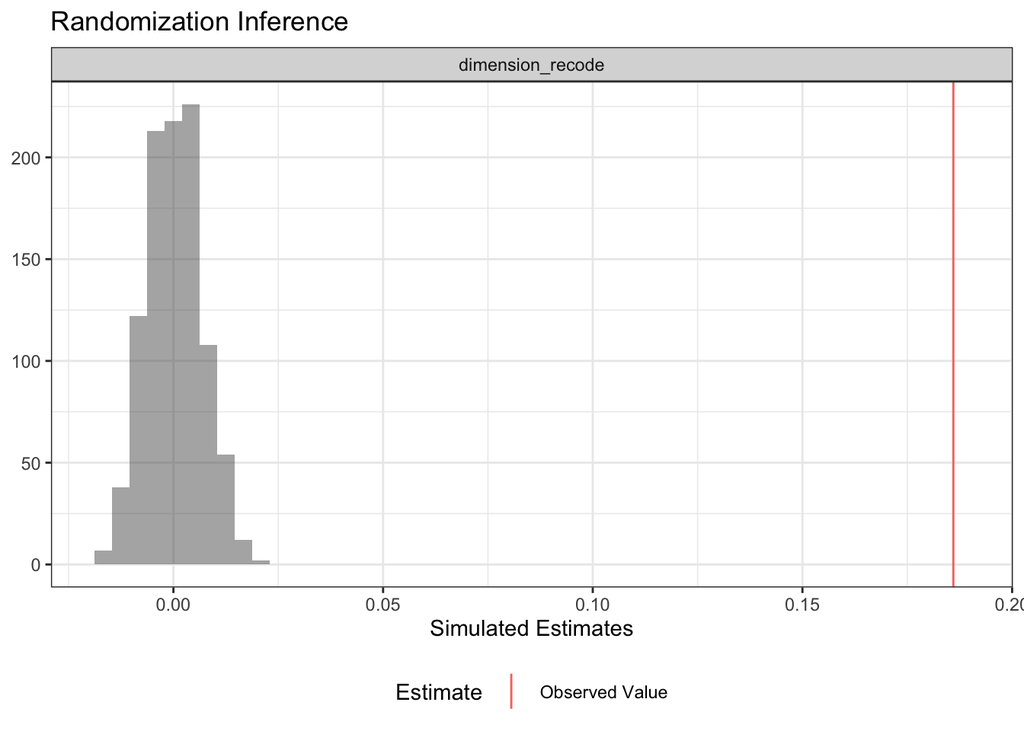

```r
plot(ri_out)
```

## Predictive Accuracy

Split data

```r
trainingData <- createDataPartition(y = df_beh$answer_recode,
                               p = .50, list = FALSE)
training <- df_beh[trainingData,]
testing <- df_beh[-trainingData,]
```

Train logistic & linear models

```r
beh_model1 <- glmer(answer_recode ~ gender_recode + age + education + subj_SES
               + pol_ideology + religiosity + support
               + dimension_recode
               + (1|country)
               + (1|dilemma),
               data=training,
               family=binomial(link = "logit"))
```

```r
format_output(beh_model1)
```

```
##                        B   SE     z      p
## Gender [Male]       0.09 0.07  1.19  0.233
## Gender [Other]     -0.71 0.37 -1.93  0.054
## Age                -0.01 0.00 -3.90 <0.001
## Education           0.00 0.03  0.11  0.915
## Subjective SES      0.00 0.02 -0.21  0.837
## Political Ideology -0.11 0.02 -4.52 <0.001
## Religiosity         0.00 0.02 -0.17  0.866
## Policy Support      0.80 0.02 40.97 <0.001
## Dimension           1.38 0.34  4.07 <0.001
```

```r
beh_model3 <- lmer(answer_recode ~ gender_recode + age + education + subj_SES
               + pol_ideology + religiosity + support
               + dimension_recode
               + (1|country)
               + (1|dilemma),
               data=training,
               REML = TRUE)
```

```r
format_output(beh_model3)
```

```
##                        B   SE   df     t      p
## Gender [Male]       0.01 0.01 6296  1.31  0.189
## Gender [Other]     -0.08 0.05 6296 -1.72  0.086
## Age                 0.00 0.00 5193 -3.78 <0.001
## Education           0.00 0.00 4855  0.04  0.971
## Subjective SES      0.00 0.00 6006 -0.07  0.942
## Political Ideology -0.01 0.00 6235 -4.84 <0.001
## Religiosity         0.00 0.00 3851  0.01  0.992
## Policy Support      0.13 0.00 6298 64.99 <0.001
## Dimension           0.18 0.05    3  3.52  0.040
```

Predictions

```r
testing$pred_glm <- predict(beh_model1, testing)
testing$pred_glm <- exp(testing$pred_glm)
testing$pred_glm <- testing$pred_glm/(1+testing$pred_glm)

testing$pred_lm <- predict(beh_model3, testing)

testing$predict_glm_error <- abs(testing$pred_glm - testing$answer_recode)
testing$predict_lm_error <- abs(testing$pred_lm - testing$answer_recode)
```

Mean error in binomal model: 0.25

Mean error in linear model: 0.27

```r
t <- t.test(testing$predict_glm_error, testing$predict_lm_error, paired = T)
```

T-test: t(6318) = -32.53, p = 0